# Coding Session / Basics

Petro Tolochko

### Data

We will be using the State of the Union dataset, available from the `sotu` package.

First, we need to install it:

We first need to install the packages required for further analysis.

```r
install.packages("sotu")
```

Load the package:

The data comes in two separate datasets – text data `sotu_text` and meta data `sotu_meta`.

```r
str(sotu_text)
```

```
##  chr [1:240] "Fellow-Citizens of the Senate and House of Representatives: \n\nI embrace with great satisfaction the opportuni"| __truncated__ ...
```

```r
str(sotu_meta)
```

```
## 'data.frame':    240 obs. of  6 variables:
##  $ X           : int  1 2 3 4 5 6 7 8 9 10 ...
##  $ president   : chr  "George Washington" "George Washington" "George Washington" "George Washington" ...
##  $ year        : int  1790 1790 1791 1792 1793 1794 1795 1796 1797 1798 ...
##  $ years_active: chr  "1789-1793" "1789-1793" "1789-1793" "1789-1793" ...
##  $ party       : chr  "Nonpartisan" "Nonpartisan" "Nonpartisan" "Nonpartisan" ...
##  $ sotu_type   : chr  "speech" "speech" "speech" "speech" ...
```

Whare are the dimensions of each dataset?

Let’s combine the two datasets together. We will do this in the `tidyverse` ecosystem.

```r
sotu_full <- bind_cols(sotu_text, sotu_meta) %>% as_tibble()
```

Inspect the data

```r
head(sotu_full)
```

```
## # A tibble: 6 × 7
##   ...1                            X president  year years_active party sotu_type
##   <chr>                       <int> <chr>     <int> <chr>        <chr> <chr>
## 1 "Fellow-Citizens of the Se…     1 George W…  1790 1789-1793    Nonp… speech
## 2 "\n\n Fellow-Citizens of t…     2 George W…  1790 1789-1793    Nonp… speech
## 3 "\n\n Fellow-Citizens of t…     3 George W…  1791 1789-1793    Nonp… speech
## 4 "Fellow-Citizens of the Se…     4 George W…  1792 1789-1793    Nonp… speech
## 5 "\n\n Fellow-Citizens of t…     5 George W…  1793 1793-1797    Nonp… speech
## 6 "\n\n Fellow-Citizens of t…     6 George W…  1794 1793-1797    Nonp… speech
```

```r
str(sotu_full)
```

```
## tibble [240 × 7] (S3: tbl_df/tbl/data.frame)
##  $ ...1        : chr [1:240] "Fellow-Citizens of the Senate and House of Representatives: \n\nI embrace with great satisfaction the opportuni"| __truncated__ "\n\n Fellow-Citizens of the Senate and House of Representatives: \n\nIn meeting you again I feel much satisfact"| __truncated__ "\n\n Fell…
##  $ X           : int [1:240] 1 2 3 4 5 6 7 8 9 10 ...
##  $ president   : chr [1:240] "George Washington" "George Washington" "George Washington" "George Washington" ...
##  $ year        : int [1:240] 1790 1790 1791 1792 1793 1794 1795 1796 1797 1798 ...
##  $ years_active: chr [1:240] "1789-1793" "1789-1793" "1789-1793" "1789-1793" ...
##  $ party       : chr [1:240] "Nonpartisan" "Nonpartisan" "Nonpartisan" "Nonpartisan" ...
##  $ sotu_type   : chr [1:240] "speech" "speech" "speech" "speech" ...
```

We need to rename some of the columns

```r
sotu_full <- sotu_full %>%
  transmute(
    text = ...1,
    id = X,
    president,
    year,
    years_active,
    party,
    type = sotu_type
  )
```

Let’s see…

```r
sotu_full
```

```
## # A tibble: 240 × 7
##    text                              id president  year years_active party type
##    <chr>                          <int> <chr>     <int> <chr>        <chr> <chr>
##  1 "Fellow-Citizens of the Senat…     1 George W…  1790 1789-1793    Nonp… spee…
##  2 "\n\n Fellow-Citizens of the …     2 George W…  1790 1789-1793    Nonp… spee…
##  3 "\n\n Fellow-Citizens of the …     3 George W…  1791 1789-1793    Nonp… spee…
##  4 "Fellow-Citizens of the Senat…     4 George W…  1792 1789-1793    Nonp… spee…
##  5 "\n\n Fellow-Citizens of the …     5 George W…  1793 1793-1797    Nonp… spee…
##  6 "\n\n Fellow-Citizens of the …     6 George W…  1794 1793-1797    Nonp… spee…
##  7 "\n\nFellow-Citizens of the S…     7 George W…  1795 1793-1797    Nonp… spee…
##  8 "\n\n Fellow-Citizens of the …     8 George W…  1796 1793-1797    Nonp… spee…
##  9 "\n\n Gentlemen of the Senate…     9 John Ada…  1797 1797-1801    Fede… spee…
## 10 "\n\n Gentlemen of the Senate…    10 John Ada…  1798 1797-1801    Fede… spee…
## # ℹ 230 more rows
```

### basic string manipulation with R

R stores the basic string in a character vector.

With `class` you can check if you are actually dealing with a character vector. `length` gets the number of items in the vector. With `[]` we can get indexed item in the vector.

With `str_length` we can retrieve the number of characters in the vector (here in the third item of the vector).

```r
class(sotu_full$text)
```

```
## [1] "character"
```

```r
length(sotu_full$text)
```

```
## [1] 240
```

```r
sotu_full$text[3]
```

```
## [1] "\n\n Fellow-Citizens of the Senate and House of Representatives: \n\n \"In vain may we expect peace with the Indians on our frontiers so long as a lawless set of unprincipled wretches can violate the rights of hospitality, or infringe the most solemn treaties, without receiving the punishmen…
```

```r
str_length(sotu_full$text[3])
```

```
## [1] 14143
```

Since functions are vectorized, we can do this for multiple observations:

```r
str_length(sotu_full$text[1:10])
```

```
##  [1]  6712  8395 14143 12703 11637 17591 12265 17320 12467 13382
```

```r
sum(str_length(sotu_full$text[1:10]))
```

```
## [1] 126615
```

```r
max(str_length(sotu_full$text[1:10]))
```

```
## [1] 17591
```

The function `paste` can be used to merge several strings

```r
sotu_full$text[1]
```

```
## [1] "Fellow-Citizens of the Senate and House of Representatives: \n\nI embrace with great satisfaction the opportunity which now presents itself of congratulating you on the present favorable prospects of our public affairs. The recent accession of the important state of North Carolina to the Con…
```

```r
sotu_full$text[2]
```

```
## [1] "\n\n Fellow-Citizens of the Senate and House of Representatives: \n\nIn meeting you again I feel much satisfaction in being able to repeat my congratulations on the favorable prospects which continue to distinguish our public affairs. The abundant fruits of another year have blessed our coun…
```

```r
paste(sotu_full$text[1], sotu_full$text[2], sep='___')
```

```
## [1] "Fellow-Citizens of the Senate and House of Representatives: \n\nI embrace with great satisfaction the opportunity which now presents itself of congratulating you on the present favorable prospects of our public affairs. The recent accession of the important state of North Carolina to the Con…
```

```r
sotu_full$party_type <- paste(sotu_full$party, sotu_full$type)
```

```r
sotu_full$party_type[1:4]
```

```
## [1] "Nonpartisan speech" "Nonpartisan speech" "Nonpartisan speech"
## [4] "Nonpartisan speech"
```

As we will see later, it is often convenient to convert all words to lowercase or uppercase.

```r
str_to_lower(sotu_full$text[1])
```

```
## [1] "fellow-citizens of the senate and house of representatives: \n\ni embrace with great satisfaction the opportunity which now presents itself of congratulating you on the present favorable prospects of our public affairs. the recent accession of the important state of north carolina to the con…
```

```r
str_to_upper(sotu_full$text[1])
```

```
## [1] "FELLOW-CITIZENS OF THE SENATE AND HOUSE OF REPRESENTATIVES: \n\nI EMBRACE WITH GREAT SATISFACTION THE OPPORTUNITY WHICH NOW PRESENTS ITSELF OF CONGRATULATING YOU ON THE PRESENT FAVORABLE PROSPECTS OF OUR PUBLIC AFFAIRS. THE RECENT ACCESSION OF THE IMPORTANT STATE OF NORTH CAROLINA TO THE CON…
```

```r
substr(sotu_full$text[1], 1, 2)
```

```
## [1] "Fe"
```

```r
substr(sotu_full$text[1], 1, 100)
```

```
## [1] "Fellow-Citizens of the Senate and House of Representatives: \n\nI embrace with great satisfaction the "
```

**Exercise:**

How do you extract the first letter of each text?

```r
# Solution
```

This is useful when working with date strings as well:

```r
sotu_full$term_begining <- substr(sotu_full$years_active, 1, 4)
sotu_full$term_end <- substr(sotu_full$years_active, 6, 9)
```

**Exercise:**

What year was the newest sotu address published?

```r
# Solution
```

Let’s now inspect the data more in detail.

Let’s see how manuy addresses mention the term `democracy`. We can use the `grep` command to identify these. `grep` returns the index where the word occurs.

```r
grep('democracy', sotu_full$text)
```

```
##  [1]  65  77 118 120 124 129 131 132 147 148 149 150 151 152 153 154 158 159 160
## [20] 162 164 165 166 175 177 180 181 182 183 184 185 192 194 198 199 201 203 204
## [39] 205 206 207 208 209 210 211 214 215 216 217 218 219 220 223 224 225 226 227
## [58] 228 230 231 233 234 235 236 240
```

`grepl` returns `TRUE` or `FALSE`, indicating whether each element of the character vector contains that particular pattern.

```r
grepl('democracy', sotu_full$text)
```

```
##   [1] FALSE FALSE FALSE FALSE FALSE FALSE FALSE FALSE FALSE FALSE FALSE FALSE
##  [13] FALSE FALSE FALSE FALSE FALSE FALSE FALSE FALSE FALSE FALSE FALSE FALSE
##  [25] FALSE FALSE FALSE FALSE FALSE FALSE FALSE FALSE FALSE FALSE FALSE FALSE
##  [37] FALSE FALSE FALSE FALSE FALSE FALSE FALSE FALSE FALSE FALSE FALSE FALSE
##  [49] FALSE FALSE FALSE FALSE FALSE FALSE FALSE FALSE FALSE FALSE FALSE FALSE
##  [61] FALSE FALSE FALSE FALSE  TRUE FALSE FALSE FALSE FALSE FALSE FALSE FALSE
##  [73] FALSE FALSE FALSE FALSE  TRUE FALSE FALSE FALSE FALSE FALSE FALSE FALSE
##  [85] FALSE FALSE FALSE FALSE FALSE FALSE FALSE FALSE FALSE FALSE FALSE FALSE
##  [97] FALSE FALSE FALSE FALSE FALSE FALSE FALSE FALSE FALSE FALSE FALSE FALSE
## [109] FALSE FALSE FALSE FALSE FALSE FALSE FALSE FALSE FALSE  TRUE FALSE  TRUE
## [121] FALSE FALSE FALSE  TRUE FALSE FALSE FALSE FALSE  TRUE FALSE  TRUE  TRUE
## [133] FALSE FALSE FALSE FALSE FALSE FALSE FALSE FALSE FALSE FALSE FALSE FALSE
## [145] FALSE FALSE  TRUE  TRUE  TRUE  TRUE  TRUE  TRUE  TRUE  TRUE FALSE FALSE
## [157] FALSE  TRUE  TRUE  TRUE FALSE  TRUE FALSE  TRUE  TRUE  TRUE FALSE FALSE
## [169] FALSE FALSE FALSE FALSE FALSE FALSE  TRUE FALSE  TRUE FALSE FALSE  TRUE
## [181]  TRUE  TRUE  TRUE  TRUE  TRUE FALSE FALSE FALSE FALSE FALSE FALSE  TRUE
## [193] FALSE  TRUE FALSE FALSE FALSE  TRUE  TRUE FALSE  TRUE FALSE  TRUE  TRUE
## [205]  TRUE  TRUE  TRUE  TRUE  TRUE  TRUE  TRUE FALSE FALSE  TRUE  TRUE  TRUE
## [217]  TRUE  TRUE  TRUE  TRUE FALSE FALSE  TRUE  TRUE  TRUE  TRUE  TRUE  TRUE
## [229] FALSE  TRUE  TRUE FALSE  TRUE  TRUE  TRUE  TRUE FALSE FALSE FALSE  TRUE
```

**Exercise:**

Check if the text of the address in row 213 includes the word `democracy`

```r
# Solution
```

We can use the results of `grep` to get particular rows. First, check how many texts mention the word `democracy`.

```r
nrow(sotu_full)
```

```
## [1] 240
```

```r
grep('democracy', sotu_full$text)
```

```
##  [1]  65  77 118 120 124 129 131 132 147 148 149 150 151 152 153 154 158 159 160
## [20] 162 164 165 166 175 177 180 181 182 183 184 185 192 194 198 199 201 203 204
## [39] 205 206 207 208 209 210 211 214 215 216 217 218 219 220 223 224 225 226 227
## [58] 228 230 231 233 234 235 236 240
```

```r
length(grep('democracy', sotu_full$text))
```

```
## [1] 65
```

It is important to note that matching is case-sensitive. You can use the `ignore.case` argument to match to a lowercase version.

```r
grep('democracy', sotu_full$text)
```

```
##  [1]  65  77 118 120 124 129 131 132 147 148 149 150 151 152 153 154 158 159 160
## [20] 162 164 165 166 175 177 180 181 182 183 184 185 192 194 198 199 201 203 204
## [39] 205 206 207 208 209 210 211 214 215 216 217 218 219 220 223 224 225 226 227
## [58] 228 230 231 233 234 235 236 240
```

```r
length(grep('democracy', sotu_full$text, ignore.case = TRUE))
```

```
## [1] 65
```

Now let’s create a new variable that tracks whether the text includes the term `democracy`.

```r
sotu_full <- sotu_full %>%
  mutate(
    democracy = grepl("democracy", text)
  )
```

**Exercise:**

Pick another keyword that you are interested. How many texts mention that keyword?

```r
# Solution
```

Let’s plot the number of appearances of `democracy` per year! We can use the `str_count` function.

```r
sotu_full <- sotu_full %>%
  mutate(dem_count = str_count(text, "democracy"))
```

Now we have a count variable `dem_count`. Let’s plot it!

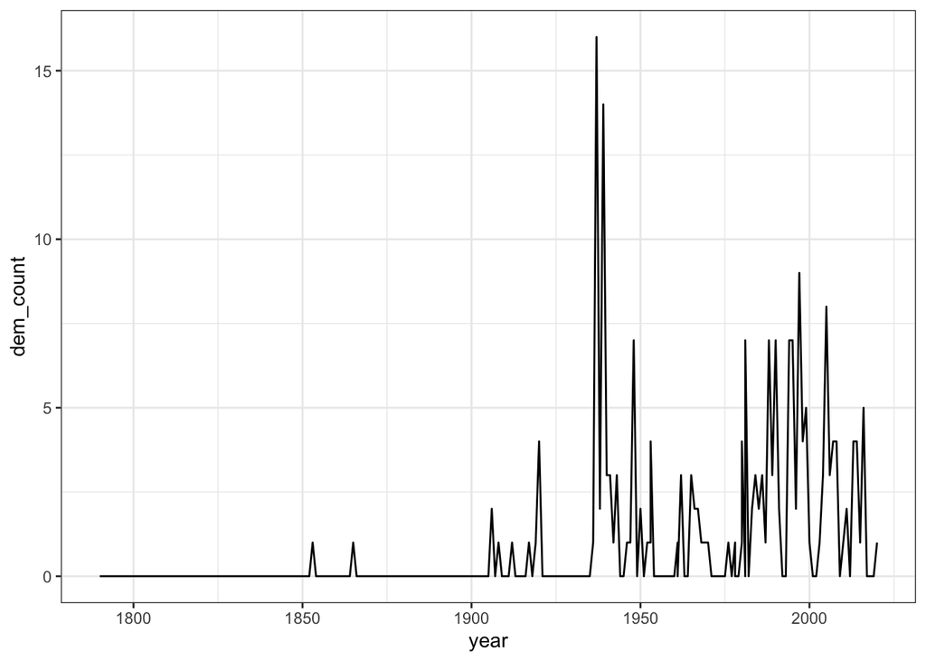

```r
sotu_full %>%
  summarise(dem_count, year) %>%
  ggplot() +
  geom_line(aes(year, dem_count)) +
  theme_bw()
```

Or, we can plot by president:

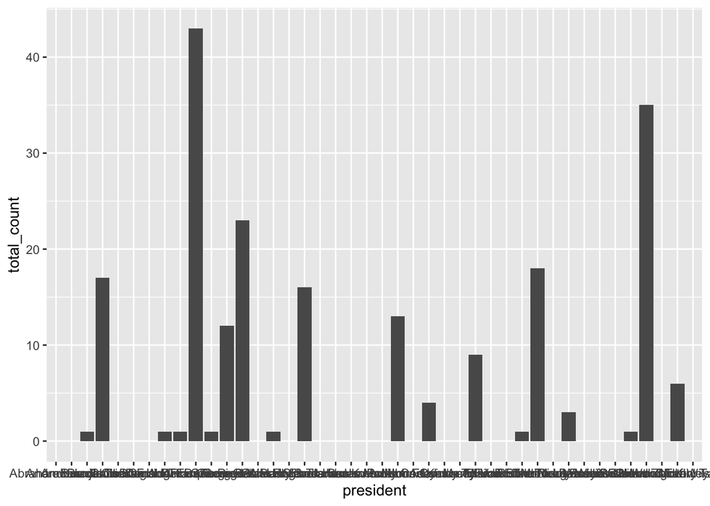

```r
sotu_full %>%
  group_by(president) %>%
  summarise(total_count = sum(dem_count)) %>%
  ggplot() +
  geom_bar(aes(president, total_count),
           stat = 'identity')
```

Doesn’t look too good… Let’s try to beautify it…

Let’s subset rows that have at least one instance of democracy:

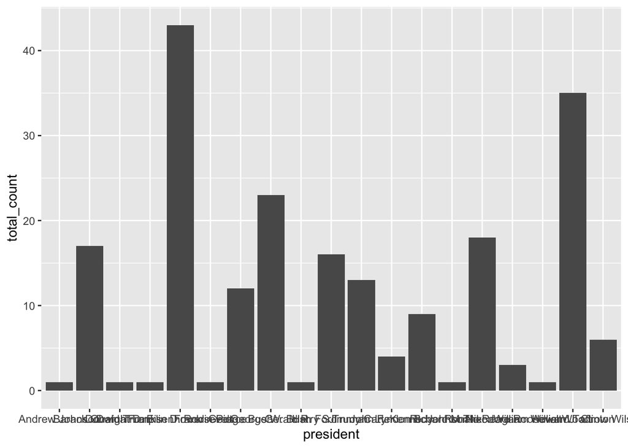

```r
sotu_full %>%
  group_by(president) %>%
  summarise(total_count = sum(dem_count)) %>%
  filter(total_count > 0) %>%
  ggplot() +
  geom_bar(aes(president, total_count),
           stat = 'identity')
```

A bit better. We can play around with the text labels:

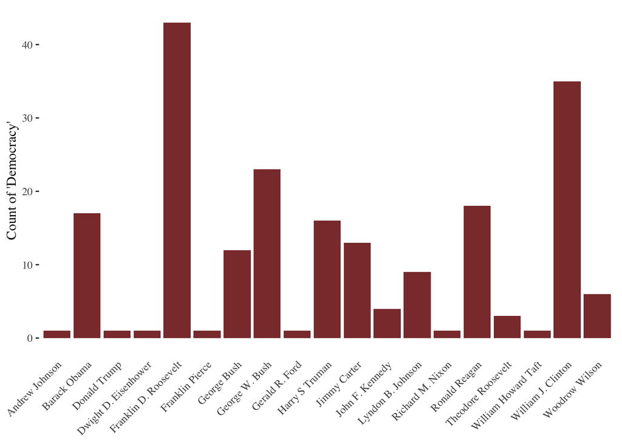

```r
sotu_full %>%
  group_by(president) %>%
  summarise(total_count = sum(dem_count)) %>%
  filter(total_count > 0) %>%
  ggplot() +
  geom_bar(aes(president, total_count),
           stat = 'identity',
           fill = 'indianred4') +
  theme_tufte() +
  theme(axis.text.x = element_text(angle = 45,
                                   hjust = 1),
        axis.ticks.x = element_blank(),
        axis.title.x = element_blank()) +
  ylab("Count of 'Democracy'")
```

We can also rearange the bars in descending order:

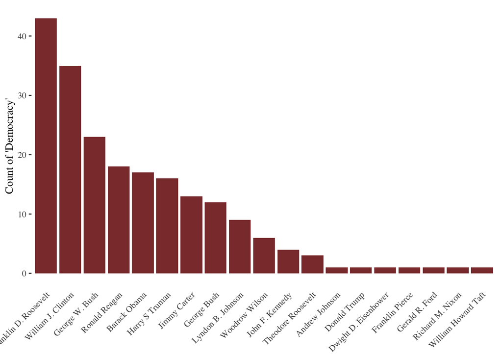

```r
sotu_full %>%
  group_by(president) %>%
  summarise(total_count = sum(dem_count)) %>%
  filter(total_count > 0) %>%
  ggplot() +
  geom_bar(aes(reorder(president, -total_count), total_count),
           stat = 'identity',
           fill = 'indianred4') +
  theme_tufte() +
  theme(axis.text.x = element_text(angle = 45,
                                   hjust = 1),
        axis.ticks.x = element_blank(),
        axis.title.x = element_blank()) +
  ylab("Count of 'Democracy'")
```

# Text representation in R

We work now with the `quanteda` package which is an R package specialized for text analysis.

```r
install.packages(c(
    "quanteda", "quanteda.textplots",
    "quanteda.textstats"))
```

```
##
##  /var/folders/_8/wv2x2gxs3jd05bn80p6kndj00000gn/T//RtmpFxtA70/downloaded_packages
```

```r
library(quanteda)
```

```r
library(quanteda.textplots)
library(quanteda.textstats)
```

In quanteda we first store our texts in a corpus object with the function corpus.

```r
my_corpus <- corpus(sotu_full, text ="text")
```

Let’s tokenize the text.

```r
my_toks <- tokens(my_corpus)
my_toks
```

```
## Tokens consisting of 240 documents and 11 docvars.
## text1 :
##  [1] "Fellow-Citizens" "of"              "the"             "Senate"
##  [5] "and"             "House"           "of"              "Representatives"
##  [9] ":"               "I"               "embrace"         "with"
## [ ... and 1,157 more ]
##
## text2 :
##  [1] "Fellow-Citizens" "of"              "the"             "Senate"
##  [5] "and"             "House"           "of"              "Representatives"
##  [9] ":"               "In"              "meeting"         "you"
## [ ... and 1,492 more ]
##
## text3 :
##  [1] "Fellow-Citizens" "of"              "the"             "Senate"
##  [5] "and"             "House"           "of"              "Representatives"
##  [9] ":"               "\""              "In"              "vain"
## [ ... and 2,461 more ]
##
## text4 :
##  [1] "Fellow-Citizens" "of"              "the"             "Senate"
##  [5] "and"             "House"           "of"              "Representatives"
##  [9] ":"               "It"              "is"              "some"
## [ ... and 2,275 more ]
##
## text5 :
##  [1] "Fellow-Citizens" "of"              "the"             "Senate"
##  [5] "and"             "House"           "of"              "Representatives"
##  [9] ":"               "Since"           "the"             "commencement"
## [ ... and 2,108 more ]
##
## text6 :
##  [1] "Fellow-Citizens" "of"              "the"             "Senate"
##  [5] "and"             "House"           "of"              "Representatives"
##  [9] ":"               "When"            "we"              "call"
## [ ... and 3,189 more ]
##
## [ reached max_ndoc ... 234 more documents ]
```

Now, we will use the function dfm to create a document-term matrix (DTM). Quanteda uses the word features as a more general label for the terms (why: it is e.g. possible to include n-grams as features)

```r
my_dfm <- dfm(my_toks)
```

Sparsity indicates the percentage of empty entries in the document-feature matrix. Here we have a highly sparse matrix. This has implications for computational efficiency and memory usage.

```r
my_dfm
```

```
## Document-feature matrix of: 240 documents, 35,709 features (94.89% sparse) and 11 docvars.
##        features
## docs    fellow-citizens  of the senate and house representatives :  i embrace
##   text1               1  69  97      2  41     3               3 3 11       1
##   text2               1  89 122      2  45     3               3 3  8       0
##   text3               1 158 240      3  73     3               3 4  6       0
##   text4               1 139 195      2  56     3               3 3 21       0
##   text5               1 132 180      2  49     3               3 3 12       0
##   text6               1 187 273      2  86     4               3 3 18       0
## [ reached max_ndoc ... 234 more documents, reached max_nfeat ... 35,699 more features ]
```

What is the most frequent feature? What is the 5th most frequent feature?

```r
textstat_frequency(my_dfm)[c(1, 5), ]
```

```
##   feature frequency rank docfreq group
## 1     the    165319    1     240   all
## 5      to     67804    5     240   all
```

Another way to visualize the most frequent features. Here, only features that occur at least twice are included.

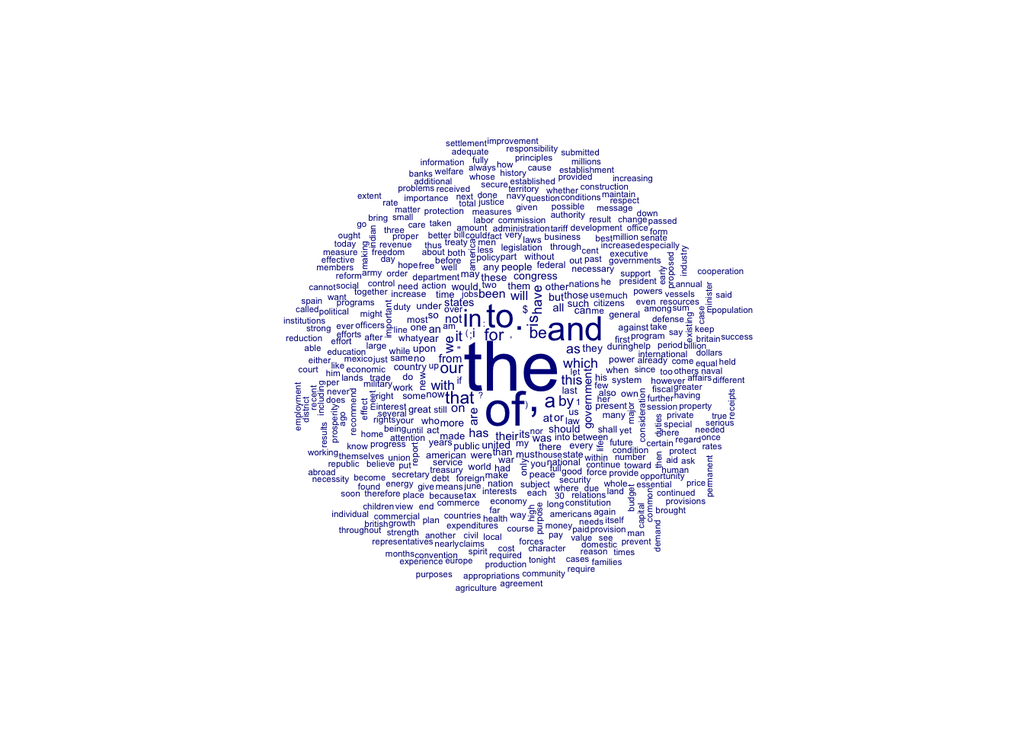

```r
textplot_wordcloud(my_dfm, min_count = 2)
```

**Exercise:**

Re-do the steps, but removing punctuation and stopwords (hint: check the help of the `tokens` function). - Apply the corpus function - Create a dfm - What are the top 3 most frequent features? - Create a word cloud with all features that occur at least 10 times.

```r
#Solution
```